# Установка R+Rstudio под Windows

Борис Демешев

21 March 2017

# Пошаговая установка R

1. Если Windows только-только поставлена, то, пожалуйста, создайте пользователя с логином английскими буквами и работайте из под него.

Например, имя пользователя “Mashenka” подходит, а “Машенька” не подходит. Английское имя сильно облегчит жизнь в дальнейшем :) Проблема в том, что при взаимодействии Rstudio - R могут возникать проблемы, если в названии папки есть русские буквы, а у “Машеньки” путь к документам выглядит как “C:/Users/Машенька/”.

Если компьютер давно используется с логином русскими буквами (“Машенька”), то оставляйте как есть, но:

```
При установке внимательно следите, что все программы ставятся в папки не содержащие русских букв. Мы рекомендуем поставить R в папку `C:/R`, а Rstudio в папку `C:/Rstudio`.
```

2. На время установки отключите антивирус.

Нет, мы не хотим подсунуть слушателям хитрый троянский вирус :) Просто встречались с проблемами при установке, если антивирус включён.

3. Установите [классический R](https://cran.r-project.org/bin/windows/base/).

Тем, кто уже знаком с R или не боится повозиться самостоятельно, мы советуем попробовать вместо классического R поставить MRO, [Microsoft R Open](https://mran.microsoft.com/open/). Это другой дистрибутив R, оптимизированный под работу с 64-битными процессорами. Всё полностью идентично, кроме двух нюансов: во-первых, MRO немного быстрее, во-вторых, MRO ставит все пакеты на единую дату, выбираемую пользователем, а классический R ставит самые свежие версии пакетов.

4. Установите [RStudio](https://www.rstudio.com/products/rstudio/download/#download).

Rstudio — это всего лишь удобная красивая графическая оболочка к R. Суровые брутальные программисты могут вполне обойтись и без Rstudio :) Не спутайте Rstudio с R-studio, платной программой для восстановления данных.

5. Настройте Rstudio.

Запустите RStudio. Зайдите в раздел Tools — Global options.

В разделе General:

```
* уберите галочку у Restore .Rdata into workspace in startup.
* выберите `Never` у Save workspace to .Rdata on exit
```

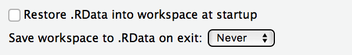

В разделе Sweave:

```
* "Weave .Rnw files using" выберите knitr.
```

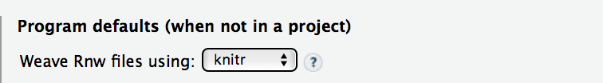

В разделе Code - Diagnostics:

```
* выставьте все галочки.
```

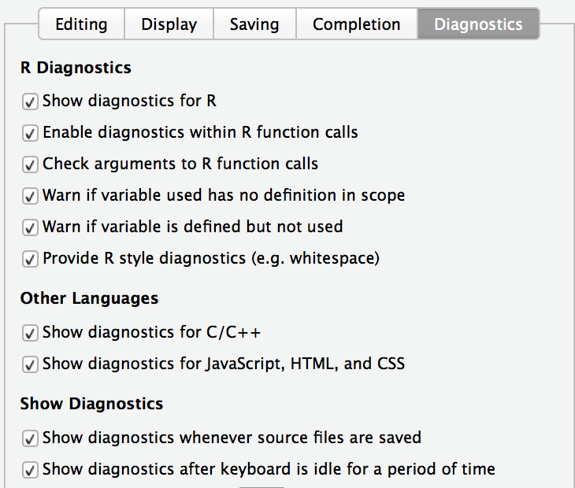

6. Установите все необходимые для курса пакеты R.

Скачайте файл install_all.R. Откройте его в RStudio (File — Open file). Запустите, выбрав Code — Source with Echo. При этом требуется соединение с Интернетом. Бегущие красные надписи не означают ошибок, признаком ошибки является только явное сообщение Error.

7. Не забудьте включить обратно антивирус :)

# Если пакеты не ставятся, то:

1. В Tools - Global options - Packages:
   - уберите галочку с “Use secure download method for HTTP”
   - в качестве CRAN mirror выберите российский репозиторий “Russia (Moscow)”

2.1. Создайте папку для установки пакетов без русских букв и пробелов, например, `C:/Rlib`

2.2. Запустите командную строку Windows. Для этого можно нажать кнопку “Пуск”, кликнуть “Выполнить”, набрать “cmd” и нажать “ok”.

2.3. В командной строке выполните

```bash
setx R_LIBS C:/Rlib
```

Вместо `C:/Rlib` должно быть имя папки созданной на шаге 2.1.

2.4. После этого запустите RStudio и проверьте, что R знает, куда ему ставить пакеты. Для этого выполните в R команду

```r
.libPaths()
```

Она должна указать путь к папке `C:/Rlib`. После этого все пакеты будут ставиться в папку `C:/Rlib`.